# Data Analysis Assignment #1 (50 points total)

Singh, Gurjus

R markdown is a plain-text file format for integrating text and R code, and creating transparent, reproducible and interactive reports. An R markdown file (.Rmd) contains metadata, markdown and R code “chunks,”" and can be “knit” into numerous output types. Answer the test questions by adding R code to the fenced code areas below each item. There are questions that require a written answer that also need to be answered. Enter your comments in the space provided as shown below:

*Answer: (Enter your answer here.)*

Once completed, you will “knit” and submit the resulting .html document and the .Rmd file. The .html will present the output of your R code and your written answers, but your R code will not appear. Your R code will appear in the .Rmd file. The resulting .html document will be graded. Points assigned to each item appear in this template.

**Before proceeding, look to the top of the .Rmd for the (YAML) metadata block, where the *title*, *author* and *output* are given. Please change *author* to include your name, with the format ‘lastName, firstName.’**

If you encounter issues with knitting the .html, please send an email via Canvas to your TA.

Each code chunk is delineated by six (6) backticks; three (3) at the start and three (3) at the end. After the opening ticks, arguments are passed to the code chunk and in curly brackets. **Please do not add or remove backticks, or modify the arguments or values inside the curly brackets.** An example code chunk is included here:

```r
# Comments are included in each code chunk, simply as prompts

#...R code placed here

#...R code placed here
```

R code only needs to be added inside the code chunks for each assignment item. However, there are questions that follow many assignment items. Enter your answers in the space provided. An example showing how to use the template and respond to a question follows.

**Example Problem with Solution:**

Use *rbinom()* to generate two random samples of size 10,000 from the binomial distribution. For the first sample, use p = 0.45 and n = 10. For the second sample, use p = 0.55 and n = 10. Convert the sample frequencies to sample proportions and compute the mean number of successes for each sample. Present these statistics.

```r
set.seed(123)
sample.one <- table(rbinom(10000, 10, 0.45)) / 10000
sample.two <- table(rbinom(10000, 10, 0.55)) / 10000

successes <- seq(0, 10)

round(sum(sample.one*successes), digits = 1) # [1] 4.5
```

```
## [1] 4.5
```

```r
round(sum(sample.two*successes), digits = 1) # [1] 5.5
```

```
## [1] 5.5
```

**Question: How do the simulated expectations compare to calculated binomial expectations?**

*Answer: The calculated binomial expectations are 10(0.45) = 4.5 and 10(0.55) = 5.5. After rounding the simulated results, the same values are obtained.*

Submit both the .Rmd and .html files for grading. You may remove the instructions and example problem above, but do not remove the YAML metadata block or the first, “setup” code chunk. Address the steps that appear below and answer all the questions. Be sure to address each question with code and comments as needed. You may use either base R functions or ggplot2 for the visualizations.

The following code chunk will:

1. load the “ggplot2”, “gridExtra” and “knitr” packages, assuming each has been installed on your machine,
2. read-in the abalones dataset, defining a new data frame, “mydata,”
3. return the structure of that data frame, and
4. calculate new variables, VOLUME and RATIO.

Do not include package installation code in this document. Packages should be installed via the Console or ‘Packages’ tab. You will also need to download the abalones.csv from the course site to a known location on your machine. Unless a *file.path()* is specified, R will look to directory where this .Rmd is stored when knitting.

```
## 'data.frame':    1036 obs. of  10 variables:
##  $ SEX   : Factor w/ 3 levels "F","I","M": 2 2 2 2 2 2 2 2 2 2 ...
##  $ LENGTH: num  5.57 3.67 10.08 4.09 6.93 ...
##  $ DIAM  : num  4.09 2.62 7.35 3.15 4.83 ...
##  $ HEIGHT: num  1.26 0.84 2.205 0.945 1.785 ...
##  $ WHOLE : num  11.5 3.5 79.38 4.69 21.19 ...
##  $ SHUCK : num  4.31 1.19 44 2.25 9.88 ...
##  $ RINGS : int  6 4 6 3 6 6 5 6 5 6 ...
##  $ CLASS : Factor w/ 5 levels "A1","A2","A3",..: 1 1 1 1 1 1 1 1 1 1 ...
##  $ VOLUME: num  28.7 8.1 163.4 12.2 59.7 ...
##  $ RATIO : num  0.15 0.147 0.269 0.185 0.165 ...
```

### Test Items starts from here - There are 6 sections

##### Section 1: (6 points) Summarizing the data.

(1)(a) (1 point) Use *summary()* to obtain and present descriptive statistics from mydata. Use *table()* to present a frequency table using CLASS and RINGS. There should be 115 cells in the table you present.

```
##  SEX         LENGTH           DIAM            HEIGHT          WHOLE
##  F:326   Min.   : 2.73   Min.   : 1.995   Min.   :0.525   Min.   :  1.625
##  I:329   1st Qu.: 9.45   1st Qu.: 7.350   1st Qu.:2.415   1st Qu.: 56.484
##  M:381   Median :11.45   Median : 8.925   Median :2.940   Median :101.344
##          Mean   :11.08   Mean   : 8.622   Mean   :2.947   Mean   :105.832
##          3rd Qu.:13.02   3rd Qu.:10.185   3rd Qu.:3.570   3rd Qu.:150.319
##          Max.   :16.80   Max.   :13.230   Max.   :4.935   Max.   :315.750
##      SHUCK              RINGS        CLASS        VOLUME
##  Min.   :  0.5625   Min.   : 3.000   A1:108   Min.   :  3.612
##  1st Qu.: 23.3006   1st Qu.: 8.000   A2:236   1st Qu.:163.545
##  Median : 42.5700   Median : 9.000   A3:329   Median :307.363
##  Mean   : 45.4396   Mean   : 9.993   A4:188   Mean   :326.804
##  3rd Qu.: 64.2897   3rd Qu.:11.000   A5:175   3rd Qu.:463.264
##  Max.   :157.0800   Max.   :25.000            Max.   :995.673
##      RATIO
##  Min.   :0.06734
##  1st Qu.:0.12241
##  Median :0.13914
##  Mean   :0.14205
##  3rd Qu.:0.15911
##  Max.   :0.31176
```

```
##
##        3   4   5   6   7   8   9  10  11  12  13  14  15  16  17  18  19  20
##   A1   9   8  24  67   0   0   0   0   0   0   0   0   0   0   0   0   0   0
##   A2   0   0   0   0  91 145   0   0   0   0   0   0   0   0   0   0   0   0
##   A3   0   0   0   0   0   0 182 147   0   0   0   0   0   0   0   0   0   0
##   A4   0   0   0   0   0   0   0   0 125  63   0   0   0   0   0   0   0   0
##   A5   0   0   0   0   0   0   0   0   0   0  48  35  27  15  13   8   8   6
##
##       21  22  23  24  25
##   A1   0   0   0   0   0
##   A2   0   0   0   0   0
##   A3   0   0   0   0   0
##   A4   0   0   0   0   0
##   A5   4   1   7   2   1
```

**Question (1 point): Briefly discuss the variable types and distributional implications such as potential skewness and outliers.**

*Answer: (There are ten variables in the data set. Sex indicates Male, Female or Infant. Class is composed of A1..A5. Length, Height, Diam, Whole, Shuck, Volume and Ratio are composed of continuous distributions. One Discrete Distribution is the RINGS variable which has integer as its type. Skewness I see are in VOLUME which has a max in the 900s and a low in a 3 so it has a large variance. SHUCK also has some skewness in the data.)*

(1)(b) (1 point) Generate a table of counts using SEX and CLASS. Add margins to this table (Hint: There should be 15 cells in this table plus the marginal totals. Apply *table()* first, then pass the table object to *addmargins()* (Kabacoff Section 7.2 pages 144-147)). Lastly, present a barplot of these data; ignoring the marginal totals.

```
## Margins computed over dimensions
## in the following order:
## 1:
## 2:
```

```
##
##         A1   A2   A3   A4   A5  sum
##   F      5   41  121   82   77  326
##   I     91  133   65   21   19  329
##   M     12   62  143   85   79  381
##   sum  108  236  329  188  175 1036
```

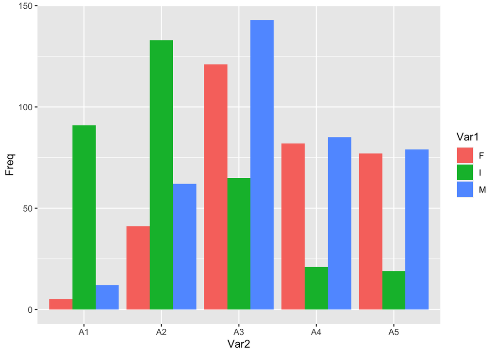

**Essay Question (2 points): Discuss the sex distribution of abalones. What stands out about the distribution of abalones by CLASS?**

*Answer: (Some points to make about sex distribution are A3 class seems to have highest frequency of Males and Females, while A2 has highest concentration of infants. Another trend i see when the concentration I see is that as the Infant concentration is low, the Female and Adult population is high. This suggests a inverse relationship between adults and infants.)*

(1)(c) (1 point) Select a simple random sample of 200 observations from “mydata” and identify this sample as “work.” Use *set.seed(123)* prior to drawing this sample. Do not change the number 123. Note that *sample()* “takes a sample of the specified size from the elements of x.” We cannot sample directly from “mydata.” Instead, we need to sample from the integers, 1 to 1036, representing the rows of “mydata.” Then, select those rows from the data frame (Kabacoff Section 4.10.5 page 87).

Using “work”, construct a scatterplot matrix of variables 2-6 with *plot(work[, 2:6])* (these are the continuous variables excluding VOLUME and RATIO). The sample “work” will not be used in the remainder of the assignment.

[figure not shown]

##### Section 2: (5 points) Summarizing the data using graphics.

(2)(a) (1 point) Use “mydata” to plot WHOLE versus VOLUME. Color code data points by CLASS.

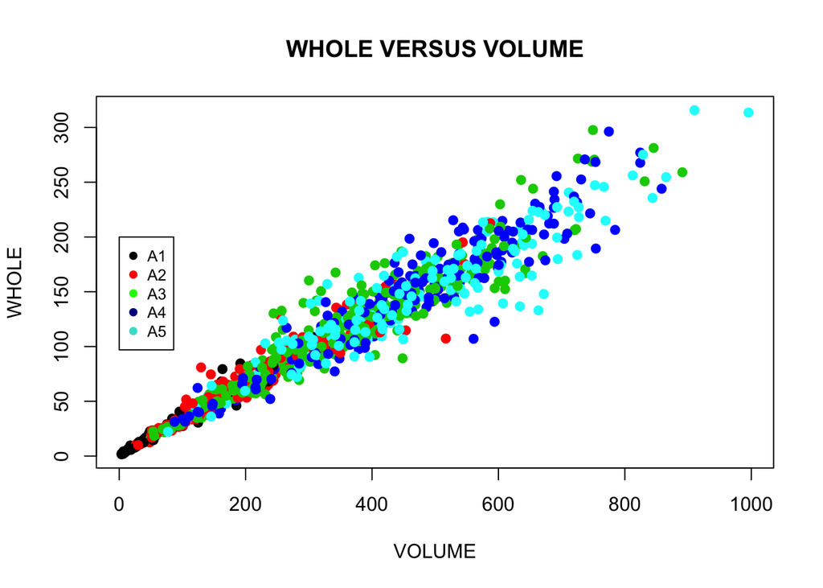

(2)(b) (2 points) Use “mydata” to plot SHUCK versus WHOLE with WHOLE on the horizontal axis. Color code data points by CLASS. As an aid to interpretation, determine the maximum value of the ratio of SHUCK to WHOLE. Add to the chart a straight line with zero intercept using this maximum value as the slope of the line. If you are using the ‘base R’ *plot()* function, you may use *abline()* to add this line to the plot. Use *help(abline)* in R to determine the coding for the slope and intercept arguments in the functions. If you are using ggplot2 for visualizations, *geom_abline()* should be used.

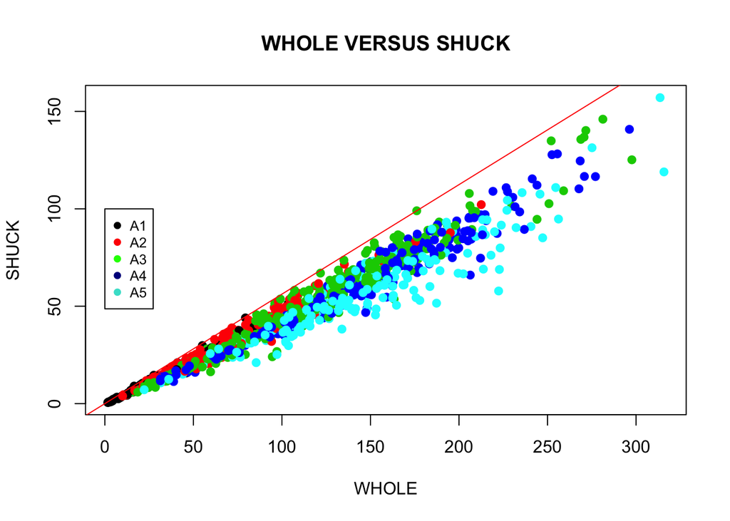

**Essay Question (2 points): How does the variability in this plot differ from the plot in (a)? Compare the two displays. Keep in mind that SHUCK is a part of WHOLE. Consider the location of the different age classes.**

*Answer: (The variability in the plot differs from plot (a) is that is that classes are more centered in part(b). What I mean by this is that there is less variance in part B in the classes than there is in part A. The data is more centered around a mean, and this means the classes are more similar than different in the variables. One class I see the most difference in is in A5. The data in A5 is more centered in the plot and has more variance in part A, but in part B it is more compact and is centered on the South end of the plot. Which refers to a lower Shuck. In terms of the trend in both plots, as the age increases the Weight and Shuck tend to increase. This means there is a linear relationship between WHOLE and SHUCK and VOLUME and WHOLE.)*

##### Section 3: (8 points) Getting insights about the data using graphs.

(3)(a) (2 points) Use “mydata” to create a multi-figured plot with histograms, boxplots and Q-Q plots of RATIO differentiated by sex. This can be done using *par(mfrow = c(3,3))* and base R or *grid.arrange()* and ggplot2. The first row would show the histograms, the second row the boxplots and the third row the Q-Q plots. Be sure these displays are legible.

[figure not shown]

**Essay Question (2 points): Compare the displays. How do the distributions compare to normality? Take into account the criteria discussed in the sync sessions to evaluate non-normality.**

(3)(b) (2 points) Use the boxplots to identify RATIO outliers (mild and extreme both) for each sex. Present the abalones with these outlying RATIO values along with their associated variables in “mydata” (Hint: display the observations by passing a data frame to the kable() function).

[figure not shown]

[figure not shown]

[figure not shown]

```
##     SEX LENGTH   DIAM HEIGHT    WHOLE     SHUCK RINGS CLASS   VOLUME      RATIO
## 350   F  7.980  6.720  2.415  80.9375  40.37500     7    A2 129.5058 0.31176204
## 379   F 15.330 11.970  3.465 252.0625 134.89812    10    A3 635.8278 0.21216140
## 420   F 11.550  7.980  3.465 150.6250  68.55375    10    A3 319.3656 0.21465603
## 421   F 13.125 10.290  2.310 142.0000  66.47062     9    A3 311.9799 0.21306058
## 458   F 11.445  8.085  3.150 139.8125  68.49062     9    A3 291.4784 0.23497668
## 586   F 12.180  9.450  4.935 133.8750  38.25000    14    A5 568.0234 0.06733877
```

```
##     SEX LENGTH   DIAM HEIGHT    WHOLE    SHUCK RINGS CLASS   VOLUME     RATIO
## 746   M 13.440 10.815  1.680 130.2500 63.73125    10    A3 244.1940 0.2609861
## 754   M 10.500  7.770  3.150 132.6875 61.13250     9    A3 256.9928 0.2378764
## 803   M 10.710  8.610  3.255 160.3125 70.41375     9    A3 300.1536 0.2345924
## 810   M 12.285  9.870  3.465 176.1250 99.00000    10    A3 420.1415 0.2356349
## 852   M 11.550  8.820  3.360 167.5625 78.27187    10    A3 342.2866 0.2286735
```

```
##     SEX LENGTH  DIAM HEIGHT    WHOLE   SHUCK RINGS CLASS     VOLUME     RATIO
## 3     I 10.080 7.350  2.205 79.37500 44.0000     6    A1 163.364040 0.2693371
## 37    I  4.305 3.255  0.945  6.18750  2.9375     3    A1  13.242072 0.2218308
## 42    I  2.835 2.730  0.840  3.62500  1.5625     4    A1   6.501222 0.2403394
## 58    I  6.720 4.305  1.680 22.62500 11.0000     5    A1  48.601728 0.2263294
## 67    I  5.040 3.675  0.945  9.65625  3.9375     5    A1  17.503290 0.2249577
## 89    I  3.360 2.310  0.525  2.43750  0.9375     4    A1   4.074840 0.2300704
## 105   I  6.930 4.725  1.575 23.37500 11.8125     7    A2  51.572194 0.2290478
## 200   I  9.135 6.300  2.520 74.56250 32.3750     8    A2 145.027260 0.2232339
```

**Essay Question (2 points): What are your observations regarding the results in (3)(b)?**

##### Section 4: (8 points) Getting insights about possible predictors.

(4)(a) (3 points) With “mydata,” display side-by-side boxplots for VOLUME and WHOLE, each differentiated by CLASS There should be five boxes for VOLUME and five for WHOLE. Also, display side-by-side scatterplots: VOLUME and WHOLE versus RINGS. Present these four figures in one graphic: the boxplots in one row and the scatterplots in a second row. Base R or ggplot2 may be used.

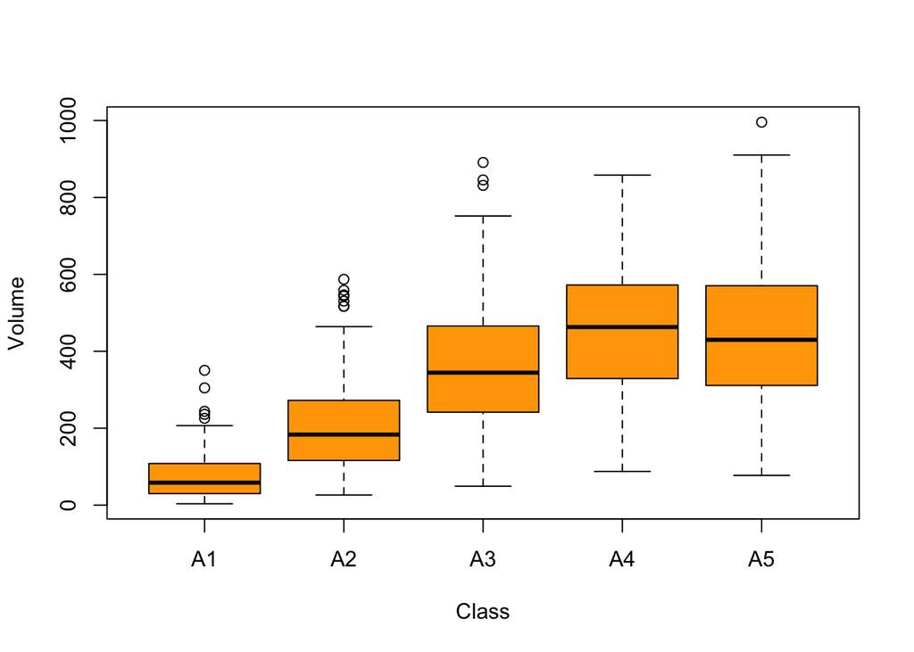

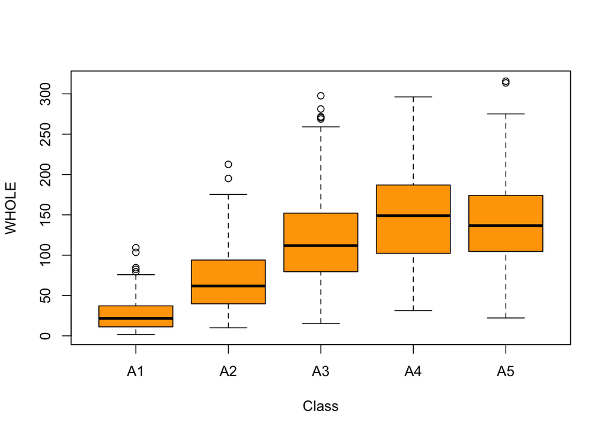

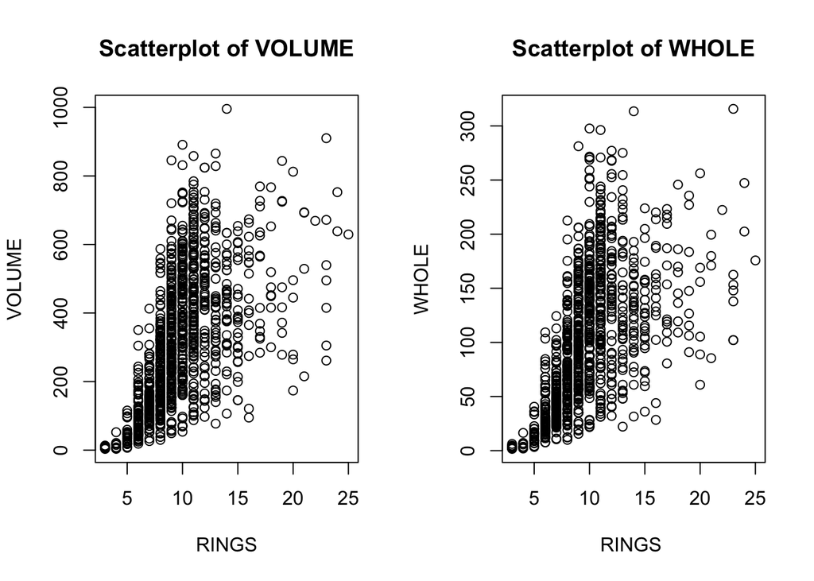

**Essay Question (5 points) How well do you think these variables would perform as predictors of age? Explain.**

##### Section 5: (12 points) Getting insights regarding different groups in the data.

(5)(a) (2 points) Use *aggregate()* with “mydata” to compute the mean values of VOLUME, SHUCK and RATIO for each combination of SEX and CLASS. Then, using *matrix()*, create matrices of the mean values. Using the “dimnames” argument within *matrix()* or the *rownames()* and *colnames()* functions on the matrices, label the rows by SEX and columns by CLASS. Present the three matrices (Kabacoff Section 5.6.2, p. 110-111). The *kable()* function is useful for this purpose. You do not need to be concerned with the number of digits presented.

|  | A1 | A2 | A3 | A4 | A5 |
| --- | --- | --- | --- | --- | --- |
| Female | 255.30 | 276.86 | 412.61 | 498.05 | 486.15 |
| Infant | 66.52 | 160.32 | 270.74 | 316.41 | 318.69 |
| Male | 103.72 | 245.39 | 358.12 | 442.62 | 440.21 |

|  | A1 | A2 | A3 | A4 | A5 |
| --- | --- | --- | --- | --- | --- |
| Female | 38.90 | 42.50 | 59.69 | 69.05 | 59.17 |
| Infant | 10.11 | 23.41 | 37.18 | 39.85 | 36.47 |
| Male | 16.39 | 38.34 | 52.97 | 61.43 | 55.03 |

|  | A1 | A2 | A3 | A4 | A5 |
| --- | --- | --- | --- | --- | --- |
| Female | 0.1560000 | 0.1553659 | 0.1442975 | 0.1379268 | 0.1236364 |
| Infant | 0.1568132 | 0.1476692 | 0.1367692 | 0.1238095 | 0.1173684 |
| Male | 0.1525000 | 0.1558065 | 0.1464336 | 0.1367059 | 0.1263291 |

(5)(b) (3 points) Present three graphs. Each graph should include three lines, one for each sex. The first should show mean RATIO versus CLASS; the second, mean VOLUME versus CLASS; the third, mean SHUCK versus CLASS. This may be done with the ‘base R’ *interaction.plot()* function or with ggplot2 using *grid.arrange()*.

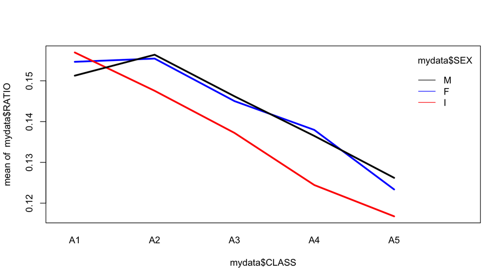

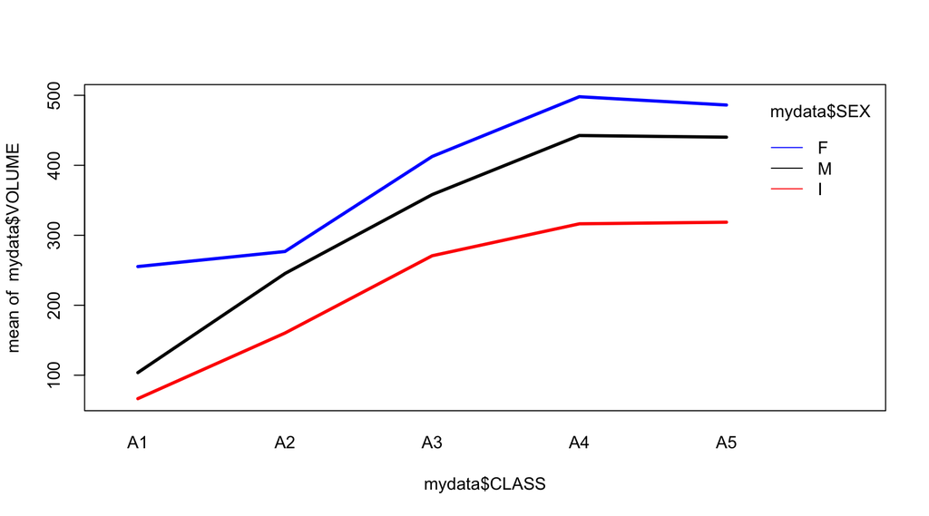

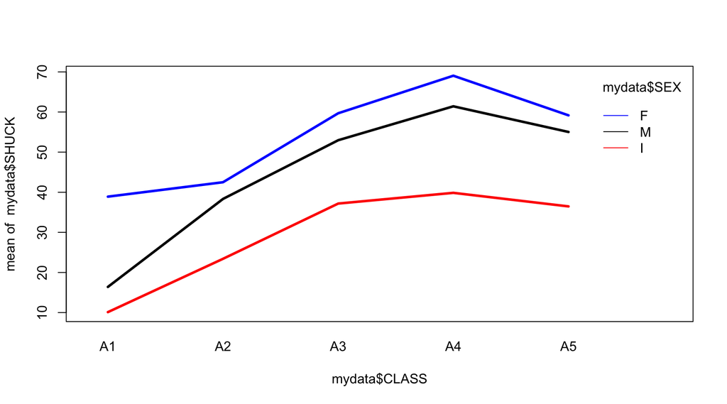

**Essay Question (2 points): What questions do these plots raise? Consider aging and sex differences.**

5(c) (3 points) Present four boxplots using *par(mfrow = c(2, 2)* or *grid.arrange()*. The first line should show VOLUME by RINGS for the infants and, separately, for the adult; factor levels “M” and “F,” combined. The second line should show WHOLE by RINGS for the infants and, separately, for the adults. Since the data are sparse beyond 15 rings, limit the displays to less than 16 rings. One way to accomplish this is to generate a new data set using subset() to select RINGS < 16. Use ylim = c(0, 1100) for VOLUME and ylim = c(0, 400) for WHOLE. If you wish to reorder the displays for presentation purposes or use ggplot2 go ahead.

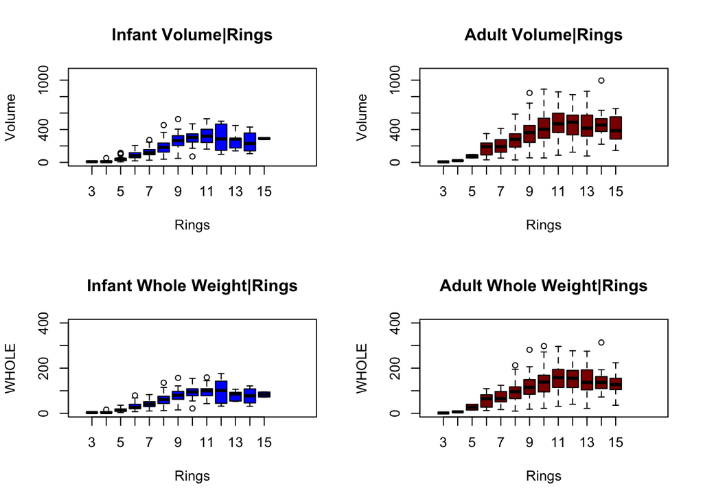

**Essay Question (2 points): What do these displays suggest about abalone growth? Also, compare the infant and adult displays. What differences stand out?**

*Answer: (The displays suggest as the rings increase the volume, and weight increase. Number of Rings is how old an abalone is. The comparison between Infant and Adult is the Adults’ Volume and WHOLE Weight have a higher increase than Infants. Another difference is Infants VOLUME and WHOLE Weight are lower than ADULTS.)*

##### Section 6: (11 points) Conclusions from the Exploratory Data Analysis (EDA).

**Conclusions**

**Essay Question 1) (5 points) Based solely on these data, what are plausible statistical reasons that explain the failure of the original study? Consider to what extent physical measurements may be used for age prediction.**

*Answer: (Plausible statistical reasons for the failure of the original study could be the sample size was not large enough. For example, the Central Limit T Theorem used in class could have been used here, but could require a sample size larger than anticipated. Also since there too many outliers, there should be wase to trim out the outliers as these could of influenced the confusing trends in the plots above. Also there is a confusion to what an Infant is in the dataset. What I mean by this is we are using CLASS, but CLASS is referred to age classfication, so how can this be used as Infants are classified less in age than adults, they could probably only be in the CLASS A1 or A2. So another reason is a failure to explain an Infant or using the data in the wrong context.)*

**Essay Question 2) (3 points) Do not refer to the abalone data or study. If you were presented with an overall histogram and summary statistics from a sample of some population or phenomenon and no other information, what questions might you ask before accepting them as representative of the sampled population or phenomenon?**

*Answer: (Some key questions I would ask does the the data only have one mode? Does the data look symmetrical? Is the sampling methods random, or nonprobability sample? I would also see what type of data was collected, what new variables were created in the study, whether the outliers should be included or should not be, such as if tthe data was mistyped or mishandled? I would also makes sure that 68% of the data is inside 1 standard deviation, and 99.7% of the data is within 3 standard deviations as mentioned in the Empirical Rule if the data is normally distributed)*

**Essay Question 3) (3 points) Do not refer to the abalone data or study. What do you see as difficulties analyzing data derived from observational studies? Can causality be determined? What might be learned from such studies?**

*Answer: (Difficulties for observational studies include the possibilties of underlying factors that affect the trend of the data, than the variables we are looking at. That is what it is really important to discuss the phrase “Correlation is not causation” as mentioned in Discussion last week. Also these difficulties can stem from human errors or incorporating irrelvant data. What I mean is that there are always human errors, but the researcher has a method of handling this data. By irrelevant data, it is important to see how valuable a certain variable is to the study. If irrelevant data is collected, then there will not be any particular insights in the data or relationships between variables.)*